# Trabecular bone strength at the distal tibia in healthy adults

Dataset 12: Muscle power and tibial bone strength in healthy adults

RSR feasibility analysis

2026-08-03

# Introduction

This is a cross-sectional laboratory study of 142 healthy adults recruited as a convenience sample from the faculty, staff and students of California State University East Bay, reported by Nickols-Richardson and colleagues in the *Journal of Musculoskeletal and Neuronal Interactions* (2022). Each participant performed a countermovement vertical jump, from which peak leg power was estimated, and had the tibia scanned by peripheral quantitative computed tomography (pQCT). The outcome here is the **bone strength index at the 4% distal tibial site**, a composite of trabecular density and cross-sectional area that indexes the ability of the bone end to resist compression; the distal tibia is a common fracture site and a standard target for exercise interventions, so knowing which everyday characteristics track with its strength is a useful descriptive question.

**Aim.** Among these healthy adults, we examined which of sex, age band, body mass and estimated peak jump power are independently associated with the trabecular bone strength index at the distal tibia, mutually adjusting for the others.

This is a *Purpose 3* analysis: several predictors are of interest and the question is which remain associated with the outcome after mutual adjustment.

# Methods

**Data source.** A convenience sample of 142 faculty, staff and students at a mid-sized regional university in the United States, measured once in a laboratory session. The published report gives a mean age of about 25 years and describes the sample as healthy and free of conditions affecting bone. The file shipped with this catalogue holds 8 columns and 142 rows, and nothing is missing.

**Variables.** The outcome is `bone_strength_index`, the compressive bone strength index at the 4% distal tibial site in mg/mm4, treated as continuous (range 43.8 to 248.3). Predictors are sex (reference female, the larger group), age band (reference Decade 2, the modal band), body mass in kilograms, and estimated peak jump power in watts. Age is supplied only as a 1-to-6 decade bin, not as exact years; the bins are consecutive ten-year bands, and given the reported mean age of about 25 years, Decade 2 corresponds to participants in their twenties. Because the file does not state the boundaries, the bands are labelled by bin number rather than by age in years.

**Predictor budget.** With 142 participants and a conventional allowance of 10 to 15 observations per estimated parameter, this dataset supports roughly 9 to 14 parameters, and the smaller end of that range is the honest target for a sample recruited by convenience. The model below spends **5 parameters** (sex 1, age band 2, body mass 1, peak power 1), i.e. 28 observations per parameter. Entering `age_decade` as an unmodified six-level factor would cost five parameters for age alone and take the model to eight; it is also not estimable in any useful sense, because decades 3, 4, 5 and 6 contain 9, 6, 5 and 2 participants. Those four bands are therefore collapsed into a single “Decades 3-6” level (n = 22). The budget was fixed before any model was fitted.

**Choosing between the two power variables.** `peak_power_w` and `relative_peak_power` must never appear in the same model, because `relative_peak_power` is exactly `peak_power_w / body_mass_kg` rounded to two decimal places: across all 142 rows the largest discrepancy is 0. The redundancy runs deeper than that. `peak_power_w` was not measured; it was calculated from the Sayers (1999) equation, *peak power (W) = 51.9 x jump height (cm) + 48.9 x body mass (kg) - 2007*, so body mass is already inside it with a fixed coefficient. Inverting the equation recovers each participant’s jump height, and the recovered values sit on a half-inch grid (largest deviation 0.00008 of a half-inch, with only 45 distinct heights in the file), which confirms the reconstruction; feeding those heights back through the equation reproduces `peak_power_w` to within 0.005 W. Three parameterisations are therefore available: body mass with absolute power, body mass with relative power, or power alone. We use **body mass and absolute peak power**, for three reasons. First, it is the parameterisation of the source paper, so the results here are directly comparable with the published analysis. Second, because power is a fixed linear combination of body mass and jump height, a model containing body mass and absolute power is *algebraically the same model* as one containing body mass and jump height, with the power coefficient equal to the jump-height coefficient divided by 51.9; this is demonstrated in the sensitivity section and it gives the adjusted power coefficient a clean physical reading. Third, `relative_peak_power` is a ratio whose denominator is another candidate predictor, and entering a ratio alongside its own denominator produces coefficients that answer no clear question. The cost of this choice is a correlation of 0.80 between body mass and peak power, which inflates their standard errors; the resulting variance inflation factors are reported with the diagnostics.

**Statistical analysis.** `lm()`, justified because the outcome is a continuous measurement with no floor or ceiling. We fitted a univariable model for each predictor first, then a single multivariable model containing all of them. Predictors were chosen in advance on subject-matter grounds, not by significance. Significance threshold 0.05; estimates are reported with 95% confidence intervals. Assumptions were checked with `performance::check_model()`, collinearity with `check_collinearity()`, and influence with Cook’s distance; because non-constant variance was flagged we additionally report HC3 heteroscedasticity-consistent standard errors. Analysis used R version 4.6.0 (2026-04-24) with tidyverse, gtsummary and performance.

**Missing data.** Complete-case analysis: 142 of 142 rows were analysed (0 dropped). Every variable in the file is 100% complete, so listwise deletion costs nothing here and the complete-case N equals the recruited N.

# Results

## Sample characteristics

**Table 1. Sample characteristics.**

| **Characteristic** | **N** | **N = 142**<sup>1</sup> |
| --- | --- | --- |
| Bone strength index (mg/mm4) | 142 | 113 (89, 146) |
| Sex | 142 |  |
| Female |  | 79 (56%) |
| Male |  | 63 (44%) |
| Age band (10-year bins) | 142 |  |
| Decade 2 |  | 89 (63%) |
| Decade 1 |  | 31 (22%) |
| Decades 3-6 |  | 22 (15%) |
| Body mass (kg) | 142 | 68 (59, 77) |
| Estimated peak jump power (W) | 142 | 3,772 (3,081, 4,528) |

<sup>1</sup> Median (Q1, Q3); n (%)

The sample is young and female-weighted: 79 women and 63 men, with 89 of 142 (63%) in the modal age band and only 22 participants in the whole of decades 3 to 6. The bone strength index has a median of 112.6 mg/mm4 with a long right tail reaching 248.3, roughly five times the minimum of 43.8.

## Exploratory figure

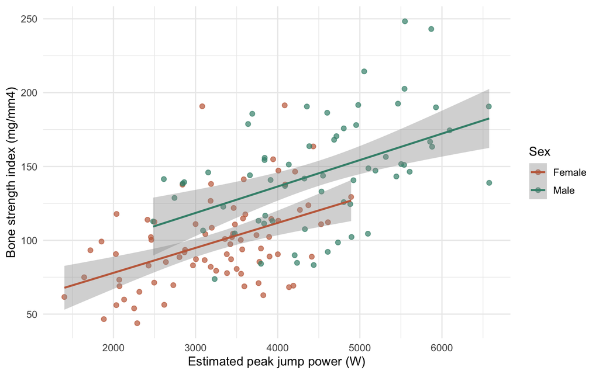

Figure 1. Trabecular bone strength index against estimated peak jump power, by sex.

## Univariable models

| **Characteristic** | **N** | **Beta** | **95% CI** | **p-value** |
| --- | --- | --- | --- | --- |
| Sex | 142 |  |  |  |
| Female |  | — | — |  |
| Male |  | 47 | 36, 58 | <0.001 |
| Age band (10-year bins) | 142 |  |  |  |
| Decade 2 |  | — | — |  |
| Decade 1 |  | -5.8 | -22, 10 | 0.5 |
| Decades 3-6 |  | -33 | -51, -14 | <0.001 |
| Body mass (kg) | 142 | 1.5 | 0.97, 2.0 | <0.001 |
| Estimated peak jump power (W) | 142 | 0.02 | 0.02, 0.03 | <0.001 |

Abbreviation: CI = Confidence Interval

Every predictor except the youngest age band shows a crude association. Each additional watt of estimated peak power is associated with 0.0240 mg/mm4 (95% CI 0.0192 to 0.0288) higher bone strength index (p <0.001), which amounts to 24.0 mg/mm4 per 1000 W; each additional kilogram of body mass with 1.49 mg/mm4 (95% CI 0.97 to 2.00) (p <0.001); and men average 46.95 mg/mm4 (95% CI 35.75 to 58.15) higher than women (p <0.001). Participants in decades 3 to 6 average -32.54 mg/mm4 (95% CI -51.10 to -13.98) relative to decade 2 (p <0.001), while decade 1 is indistinguishable from decade 2 (-5.80 mg/mm4 (95% CI -22.06 to 10.46), p = 0.482).

## Why adjustment is needed

**Body mass** confounds the crude peak-power association in a way that is unusually explicit in this dataset: heavier participants have higher estimated peak power partly because they jumped higher, but also partly by construction, since body mass enters the Sayers equation with a coefficient of 48.9 W per kilogram. Body mass is separately associated with bone strength because bone adapts to the load it habitually carries, so a crude power coefficient is carrying a mass effect on both counts. **Sex** confounds the same association from the other direction: men in this sample are heavier (median 72.8 versus 61.7 kg) and more powerful (median 4552 versus 3380 W), and men have larger, stronger tibiae for reasons of skeletal size and hormonal history that have nothing to do with jumping, so the crude power slope is partly a comparison of men with women. **Age band** works on both: the older participants here are both less powerful (mean peak power 3195 W in decades 3-6 versus 3968 W in decade 2) and losing trabecular bone with age. Mutual adjustment lets each coefficient be read as a comparison between participants of the same sex, age band and body mass.

## Multivariable model

| **Characteristic** | **Beta** | **95% CI** | **p-value** |
| --- | --- | --- | --- |
| Sex |  |  |  |
| Female | — | — |  |
| Male | 24 | 12, 36 | <0.001 |
| Age band (10-year bins) |  |  |  |
| Decade 2 | — | — |  |
| Decade 1 | 0.98 | -11, 13 | 0.9 |
| Decades 3-6 | -14 | -29, 0.30 | 0.055 |
| Body mass (kg) | -0.43 | -1.1, 0.28 | 0.2 |
| Estimated peak jump power (W) | 0.02 | 0.01, 0.03 | <0.001 |

Abbreviation: CI = Confidence Interval

**Model fit: multivariable linear model for bone strength index**

| Statistic | Value |
| --- | --- |
| Complete-case N | 142 |
| Parameters (excl. intercept) | 5 |
| Observations per parameter | 28.4 |
| R-squared | 0.497 |
| Adjusted R-squared | 0.478 |
| Residual SE (mg/mm4) | 29.48 |

## Unadjusted versus adjusted

**Table 2. Unadjusted and adjusted estimates.**

| **Characteristic** | **Unadjusted** **N** | **Unadjusted** **Beta** | **Unadjusted** **95% CI** | **Unadjusted** **p-value** | **Adjusted** **Beta** | **Adjusted** **95% CI** | **Adjusted** **p-value** |
| --- | --- | --- | --- | --- | --- | --- | --- |
| Sex | 142 |  |  |  |  |  |  |
| Female |  | — | — |  | — | — |  |
| Male |  | 47 | 36, 58 | <0.001 | 24 | 12, 36 | <0.001 |
| Age band (10-year bins) | 142 |  |  |  |  |  |  |
| Decade 2 |  | — | — |  | — | — |  |
| Decade 1 |  | -5.8 | -22, 10 | 0.5 | 0.98 | -11, 13 | 0.9 |
| Decades 3-6 |  | -33 | -51, -14 | <0.001 | -14 | -29, 0.30 | 0.055 |
| Body mass (kg) | 142 | 1.5 | 0.97, 2.0 | <0.001 | -0.43 | -1.1, 0.28 | 0.2 |
| Estimated peak jump power (W) | 142 | 0.02 | 0.02, 0.03 | <0.001 | 0.02 | 0.01, 0.03 | <0.001 |

Abbreviation: CI = Confidence Interval

Two estimates move a long way. **Body mass** collapses from 1.49 mg/mm4 (95% CI 0.97 to 2.00) crude to -0.43 mg/mm4 (95% CI -1.14 to 0.28) adjusted, crossing the null and losing significance entirely (p <0.001 to p = 0.231): almost the whole crude association between body mass and trabecular bone strength is shared with peak power, which is unsurprising given that the two are correlated at 0.80 and that body mass is a component of the power calculation. **Sex** halves, from 46.95 mg/mm4 (95% CI 35.75 to 58.15) to 24.01 mg/mm4 (95% CI 11.63 to 36.39), moving toward the null but remaining clearly significant, so roughly half of the crude male advantage is explained by men being heavier and more powerful and half is not. The **decades 3-6** contrast also attenuates markedly, from -32.54 mg/mm4 (95% CI -51.10 to -13.98) to -14.17 mg/mm4 (95% CI -28.65 to 0.30), and crosses from significant (p <0.001) to non-significant (p = 0.055) - the older participants have lower bone strength largely because they are less powerful, not independently of it. By contrast **peak power barely moves**, from 0.0240 mg/mm4 (95% CI 0.0192 to 0.0288) crude to 0.0203 mg/mm4 (95% CI 0.0113 to 0.0292) adjusted; it loses about 16% of its magnitude and gains width in its interval because it is competing with body mass for the same variance, but it stays significant throughout. The **decade 1** contrast is negligible in both columns.

## Diagnostics

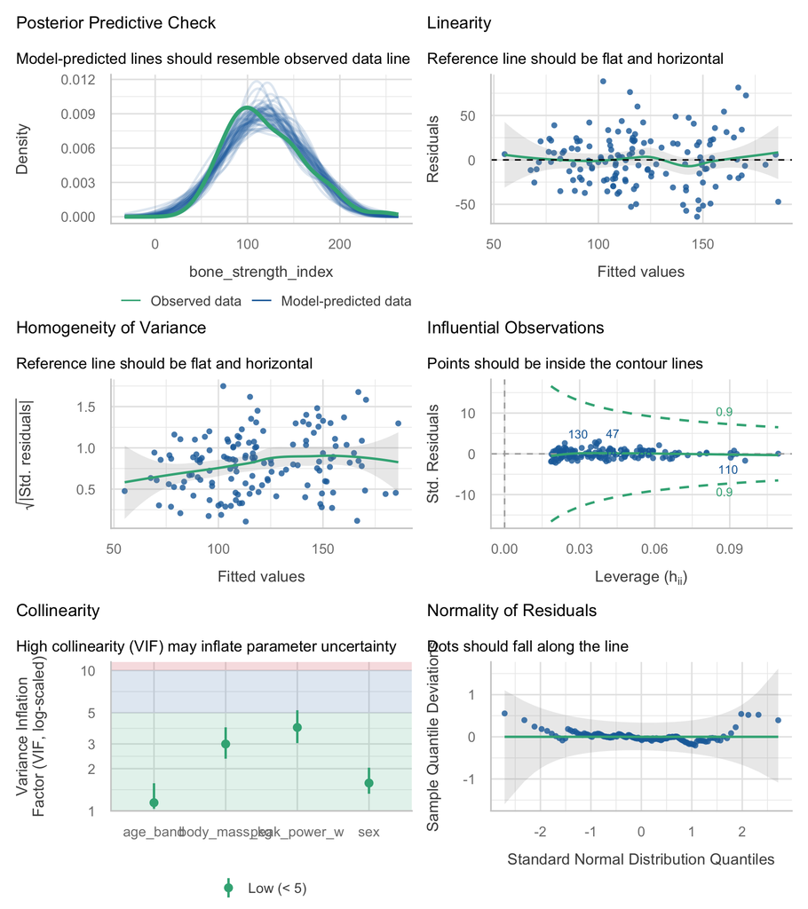

| Term | VIF | VIF_CI_low | VIF_CI_high | SE_factor | Tolerance | Tolerance_CI_low | Tolerance_CI_high |
| --- | --- | --- | --- | --- | --- | --- | --- |
| sex | 1.579331 | 1.325470 | 2.031200 | 1.256714 | 0.6331795 | 0.4923198 | 0.7544495 |
| age_band | 1.144973 | 1.036585 | 1.574474 | 1.034425 | 0.8733829 | 0.6351328 | 0.9647061 |
| body_mass_kg | 2.994820 | 2.354574 | 3.937680 | 1.730555 | 0.3339099 | 0.2539566 | 0.4247053 |
| peak_power_w | 3.929193 | 3.038890 | 5.208257 | 1.982219 | 0.2545052 | 0.1920028 | 0.3290675 |

**Table 3. Coefficients with and without the single most influential observation (Cook’s D = 0.061).**

| Term | Full sample | Most influential dropped | Change (%) |
| --- | --- | --- | --- |
| sexMale | 24.0107 | 24.8835 | 3.6 |
| age_bandDecade 1 | 0.9841 | -1.6992 | -272.7 |
| age_bandDecades 3-6 | -14.1726 | -14.0245 | 1.0 |
| body_mass_kg | -0.4319 | -0.3893 | 9.9 |
| peak_power_w | 0.0203 | 0.0200 | -1.2 |

```
## OK: residuals appear as normally distributed (p = 0.157).
```

**Table 4. HC3 heteroscedasticity-consistent standard errors.**

| Term | Estimate | SE (OLS) | SE (HC3) | 95% CI (HC3) | p (HC3) |
| --- | --- | --- | --- | --- | --- |
| sexMale | 24.0107 | 6.2586 | 6.1271 | 11.894 to 36.127 | 0.000 |
| age_bandDecade 1 | 0.9841 | 6.2891 | 6.3916 | -11.656 to 13.624 | 0.878 |
| age_bandDecades 3-6 | -14.1726 | 7.3209 | 5.8520 | -25.745 to -2.600 | 0.017 |
| body_mass_kg | -0.4319 | 0.3594 | 0.3206 | -1.066 to 0.202 | 0.180 |
| peak_power_w | 0.0203 | 0.0045 | 0.0045 | 0.011 to 0.029 | 0.000 |

**Linearity and homogeneity of variance.** The residual-versus-fitted panel shows a mild fan: spread grows with the fitted value, and `check_heteroscedasticity()` flags non-constant error variance (p = 0.004). This is the expected consequence of a right-skewed outcome whose variability scales with its level. Table 4 therefore reports HC3 robust standard errors, and the substantive conclusions are unchanged: peak power keeps p <0.001, and the decades 3-6 contrast in fact becomes significant under robust inference (p = 0.017) because its OLS standard error was conservative.

**Collinearity.** The variance inflation factors are 3.93 for peak power and 2.99 for body mass, with sex at 1.58 and age band at 1.14. These are below the conventional threshold of 5 but they are the direct price of the parameterisation chosen in Methods, and they are the reason the body-mass coefficient has a confidence interval wide enough to span zero comfortably.

**Influential observations.** This matters more than usual at n = 142, where one participant is 0.7% of the sample. The largest Cook’s distance is 0.061, far below the conventional concern threshold of 0.5, and the largest leverage is 0.109; 6 observations exceed the stricter 4/n rule but none dominates. Table 3 confirms this directly: refitting without the single most influential participant changes the peak-power coefficient by only 1.2% and the sex coefficient by 3.6%. The only coefficient that swings proportionally is the decade 1 contrast, which moves from 0.98 to -1.70 mg/mm4 - a large percentage change only because the estimate is close to zero to begin with, and immaterial next to its standard error of 6.29.

## Sensitivity: alternative parameterisations

**Table 5. The same data under five parameterisations of body mass and power.**

| Model | Parameters | R-squared | Adjusted R-squared | Residual SE | Max VIF |
| --- | --- | --- | --- | --- | --- |
| Chosen: body mass + absolute power | 5 | 0.497 | 0.478 | 29.48 | 3.9 |
| Equivalent: body mass + jump height | 5 | 0.497 | 0.478 | 29.48 | 1.7 |
| Alternative: body mass + relative power | 5 | 0.488 | 0.469 | 29.74 | 1.6 |
| Absolute power only (no body mass) | 4 | 0.491 | 0.476 | 29.53 | 1.6 |
| WRONG: all three power/mass terms | 6 | 0.499 | 0.477 | 29.52 | 89.0 |

Table 5 makes the argument of the Methods section concrete. The chosen model and the jump-height model have **identical** R-squared (0.496510 versus 0.496510) and identical residual standard error, because they are the same model written twice: multiplying the peak-power coefficient by 51.9 gives 1.05166884, against a jump-height coefficient of 1.05166884 mg/mm4 per centimetre - the same number to eight decimal places, not merely a similar one. Read this way, the adjusted “power” effect is really a jump-height effect, and the negative body-mass coefficient in the main model is an artefact of holding a mass-containing composite fixed: in the jump-height parameterisation, body mass is associated with 0.56 mg/mm4 per kilogram (p = 0.019), which is positive, as biology would expect.

Substituting relative for absolute power changes little (R-squared 0.488 against 0.497) and lowers the maximum VIF, so a student who chose that parameterisation would reach the same substantive conclusion by a different route. The last row is the trap: entering body mass, absolute power *and* relative power together buys almost nothing in fit (R-squared 0.499) while pushing the maximum variance inflation factor to 89, whereupon peak power loses significance (p = 0.085) and relative power takes a meaningless negative coefficient of -1.17. Nothing in that column should be interpreted.

Finally, because the outcome is right-skewed and the variance is non-constant, we refitted on the log scale. Heteroscedasticity is resolved (p = 0.536), the fit is essentially unchanged (R-squared 0.500), and the conclusions hold: each 1000 W of peak power is associated with 16.2% higher bone strength index (p <0.001) and men are 23.5% higher than women (p <0.001). The natural-scale model is retained as primary because its coefficients are in the units clinicians and the source paper use, with HC3 standard errors doing the inferential work.

# Discussion

Among these 142 healthy adults, **estimated peak leg power is the characteristic most strongly and independently associated with trabecular bone strength at the distal tibia**: about 20 mg/mm4 per 1000 W, holding sex, age band and body mass constant. Men average about 24 mg/mm4 more than women who are alike on the other three. The crude association with body mass does not survive adjustment; once the sensitivity analysis is read alongside it, the picture is that *how hard a person can push off the ground*, rather than *how much they weigh*, is what tracks with the strength of the bone end. Practically, this is consistent with the idea that high-rate loading rather than static weight-bearing is what the distal tibia responds to, which is the rationale behind jumping and plyometric exercise programmes for bone. It does not demonstrate that such programmes work.

**Limitations.** The design is **cross-sectional**, so temporality is unknown and reverse causation is entirely plausible: people with stronger tibiae may simply be the people who have always jumped, played sport and stayed active, in which case the arrow runs from bone to power as much as from power to bone. The sample is a **convenience sample of one university’s staff and students**, young (63% in a single decade band) and healthy, so nothing here generalises to older adults or to anyone at real fracture risk - the age coefficients in particular rest on 22 participants above decade 2 and are wide. **Peak power was estimated, not measured**: it is the Sayers regression equation applied to jump height and body mass, and the jump heights themselves are recorded to the nearest half inch, giving only 45 distinct values. Measurement error in a predictor attenuates its coefficient toward the null, so the true association with genuinely measured peak power is if anything *stronger* than reported here; it also means the “power” variable is partly a restatement of body mass, which is why the two compete (VIF 3.9). **Age is a decade bin, not a number**, so any age gradient is measured crudely and decades 3 to 6 had to be merged. Physical activity, calcium and vitamin D intake, smoking, menstrual and hormonal history, tibial length and limb dominance are **not measured at all**, and several of them plausibly cause both muscle power and bone strength, so residual confounding is certain. Residual variance is non-constant; HC3 standard errors address inference but not the model’s fit to the upper tail. All estimates are associations, not causal effects.

**Future work.** A prospective study with directly measured force-plate power, exact ages and an activity history would settle whether the power-bone association is a training effect or a shared constitutional one.

# Feasibility notes

*NOT part of a student report.*

- **USABLE.** This is a clean, well-behaved linear outcome with a genuine finding, no missing data and a defensible model at 28.4 observations per parameter. It is one of the simpler datasets in the catalogue, and the simplicity is the point: the whole difficulty is in choosing the predictor parameterisation, not in cleaning.
- **MAJOR trap: `peak_power_w` and `relative_peak_power` are the same variable.** `relative_peak_power` is exactly `peak_power_w / body_mass_kg` rounded to 2 dp (largest discrepancy across all 142 rows: 0). Putting both in one model, with body mass, gives VIFs of 89, 36 and 31, flips the sign of relative power and kills the significance of peak power. The catalogue’s own suggested predictor list contains **both**, so a student following it literally will hit this. This must be flagged in `meta.json`.
- **MAJOR trap: `peak_power_w` already contains `body_mass_kg`.** It is the Sayers (1999) equation, `PP = 51.9*jump_cm + 48.9*body_mass - 2007`, inverted; the recovered jump heights land on a half-inch grid to within 0.00008 and reproduce `peak_power_w` to 0.005 W. Consequences: (a) `cor(body_mass, peak_power) = 0.80`, VIF 3.9; (b) the adjusted body-mass coefficient is **negative** (-0.43) purely because it is conditioning on a mass-containing composite, which a student will almost certainly misinterpret as “heavier people have weaker bone”. The source paper reports the same negative standardised coefficient (-0.102) without explaining it. This is the single most likely way a student writes a confidently wrong discussion.
- **MAJOR: `age_decade` cannot be used as a six-level factor.** Cell sizes are 31, 89, 9, 6, 5, 2 for decades 1 through 6, so decade 6 holds 2 participants and there are no men at all in decades 4 or 6. As a six-level factor the largest standard error is 22.0 mg/mm4 and the extra three degrees of freedom buy nothing (F test against the collapsed model p = 0.50). Collapsing to three bands is required, not optional.
- **MINOR: heteroscedasticity** (p = 0.004). Normality of residuals passes (p = 0.157), so this is the milder of the two problems and a log transform fixes it (p = 0.536) without changing conclusions. A student who reports the untransformed model without HC3 has one failed check on the record.
- **MINOR: no influential-point problem.** Maximum Cook’s distance 0.061, maximum leverage 0.109, and dropping the most influential participant moves the peak-power coefficient by 1.2%. Worth checking because n = 142, but it comes out clean for this outcome (contrast `polar_strength_strain_index`, where the same check moves a coefficient by 22%).
- **MINOR: no binary outcome exists in this file, and none should be manufactured.** A student will be tempted to split the bone strength index at its median or a percentile to run a logistic model. There is **no clinical threshold** for BSI in healthy adults - unlike, say, a T-score, this index has no reference population or diagnostic cut-point - so any dichotomy would be arbitrary, would throw away the information that gives this analysis its R-squared of 0.50, and would produce an “outcome” that answers no question anyone asks. The dataset supports a **linear project only**, and `index.html` correctly says so.
- **MINOR: the two outcomes are correlated at 0.69** (Pearson), i.e. they share 48% of their variance. They are *not* redundant: they measure different bone compartments at different sites, the residual correlation after this model is only 0.45, and they give different answers - peak power dominates here while body mass dominates for the shaft. Offering both is justified.
- **Sample size is the binding constraint.** 142 participants and five candidate predictors, two of which cannot coexist, leaves essentially one sensible model. There is no room for interactions, splines or subgroup analyses, and students should be told that plainly rather than discovering it.